# Quel est le lien entre nombre de kills et victoire ?

## On veut voir si il y a un lien entre le nombre de kills et gagner la manche, ou si la victoire est plutôt liée à la coordination autour de l’objectif.

```r
library(dplyr)
```

```r
library(purrr)
library(readr)

base_path <- "./data/3. Valorant Champion Tour 2021-2026 Data"
years     <- 2021:2026
folders   <- file.path(base_path, paste0("vct_", years))

process_round_file <- function(folder_path) {
  outcome_path <- file.path(folder_path, "matches", "win_loss_methods_round_number.csv")
  kills_path   <- file.path(folder_path, "matches", "rounds_kills.csv")

  if (file.exists(outcome_path) && file.exists(kills_path)) {
    df_outcome <- read_csv(outcome_path, show_col_types = FALSE)
    df_kills   <- read_csv(kills_path, show_col_types = FALSE)

    team_kills <- df_kills %>%
      group_by(`Tournament`, `Match Name`, Map, `Round Number`, `Eliminator Team`) %>%
      summarise(Total_Kills = n_distinct(Eliminated), .groups = "drop") %>%
      rename(Team = `Eliminator Team`)

    merged_data <- df_outcome %>%
      left_join(team_kills, by = c("Tournament", "Match Name", "Map", "Round Number", "Team")) %>%
      mutate(Total_Kills = coalesce(Total_Kills, 0L))

    return(merged_data)

  } else if (file.exists(outcome_path)) {
    df_outcome <- read_csv(outcome_path, show_col_types = FALSE)
    return(df_outcome %>% mutate(Total_Kills = NA_integer_))
  }
  return(NULL)
}

round_outcome <- map_df(folders, process_round_file)

final_display <- round_outcome %>%
  select(Tournament, `Match Name`, Map, `Round Number`, Team, Total_Kills, Outcome) %>%
  arrange(`Match Name`, Map, `Round Number`, desc(Outcome))
```

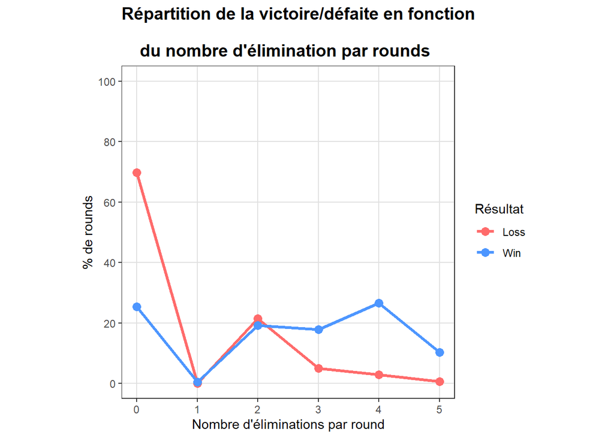

```r
library(ggplot2)
library(dplyr)

pct_data <- final_display %>%
  group_by(Outcome, Total_Kills) %>%
  summarise(Count = n(), .groups = "drop_last") %>%
  mutate(Pct = (Count / sum(Count)) * 100) %>%
  ungroup()

ggplot(pct_data, aes(x = Total_Kills, y = Pct, color = Outcome, group = Outcome)) +
  geom_line(size = 1.2) +
  geom_point(size = 3) +

  scale_color_manual(values = c("Win" = "#4D96FF", "Loss" = "#FF6B6B")) +

  scale_x_continuous(limits = c(0, 5), breaks = 0:5) +
  scale_y_continuous(limits = c(0, 100), breaks = seq(0, 100, 20)) +

  coord_fixed(ratio = 1/20) +

  labs(
    title = "Répartition de la victoire/défaite en fonction\n
    du nombre d'élimination par rounds",
    x = "Nombre d'éliminations par round",
    y = "% de rounds",
    color = "Résultat"
  ) +
  theme_bw() +
  theme(
    plot.title = element_text(face = "bold", size = 14),
    panel.grid.major = element_line(color = "#e0e0e0"),
    panel.grid.minor = element_blank()
  )
```

Comme on peut le voir dans ce grpahique, le nombre d’éliminations et la victoire sont corrélés de façon particulière. Dans le cas d’un coach d’équipe E-Sport, il peut être capital de savoir comment ceux-ci sont liés. On voit qu’à 1 kill, le nombre de parties est quasiment 0, car les manches où le nombre d’éliminations est de 1 est extrêmement rare, les joueurs répliquent lorsqu’un de leur allié est éliminé. On voit aussi que 2 éliminations ne sont souvent pas suffisantes, mais que quand la majorité de l’équipe adverse est éliminée, c’est très souvent le signe d’une victoire. Dans le cas contraire, ne pas faire d’élimination montre que dans l’écrasante majorité des cas, on a subit une défaite.